# scom-cam colab

## 231019: descriptives

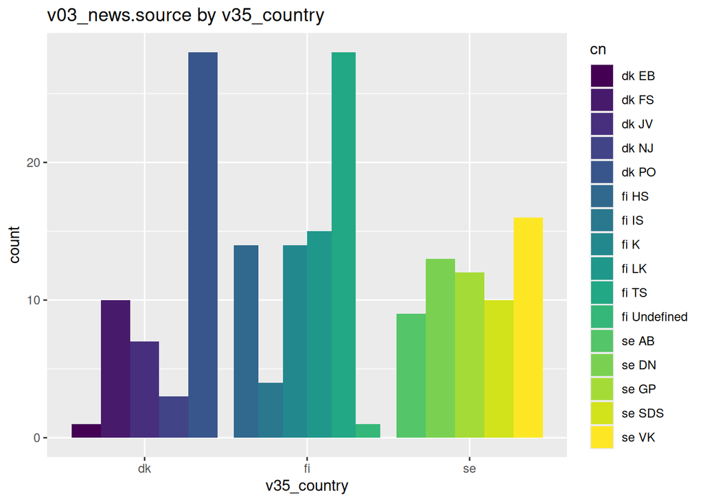

```r
pd = data |> group_by(v03_news.source, v35_country) |> summarize(count=n()) |>
left_join(dt03, by=join_by(v03_news.source==V2)) |>
mutate(cn=paste(v35_country, V3), cc=as.factor(v35_country))
p1 = ggplot(pd, aes(x=v35_country, y=count, fill=cn)) +
    geom_bar(stat="identity", position=position_dodge()) +
    scale_fill_discrete(name=pd$V1[1]) +
    labs(y="count", x="v35_country", title="v03_news.source by v35_country")

#    scale_fill_discrete(name=pd$V1[1], labels=V3)
#    scale_fill_manual(values=pd$cx)
#    scale_color_viridis(discrete=T) +
#p1 + scale_fill_brewer(colorRampPalette(brewer.pal(9,"YlOrRd"))(50))
#p1 + scale_fill_manual(values=colorRampPalette(brewer.pal(9,"Spectral"))(nrow(unique(pd[,1]))))
p1 + scale_fill_manual(values=viridis(nrow(unique(pd[,1]))))
```

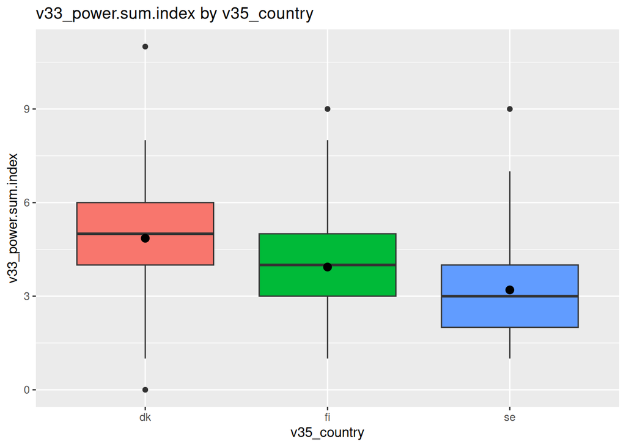

```r
pd = data |> select(35,33) |> rename(v35=1, v33=2)
p1 = ggplot(pd, aes(x=v35, y=v33, fill=v35)) +
    geom_boxplot(alpha=1.0) +
    stat_summary(fun=mean) +
    labs(y="v33_power.sum.index", x="v35_country", title="v33_power.sum.index by v35_country") +
    theme(legend.position="none")

#
p1
```

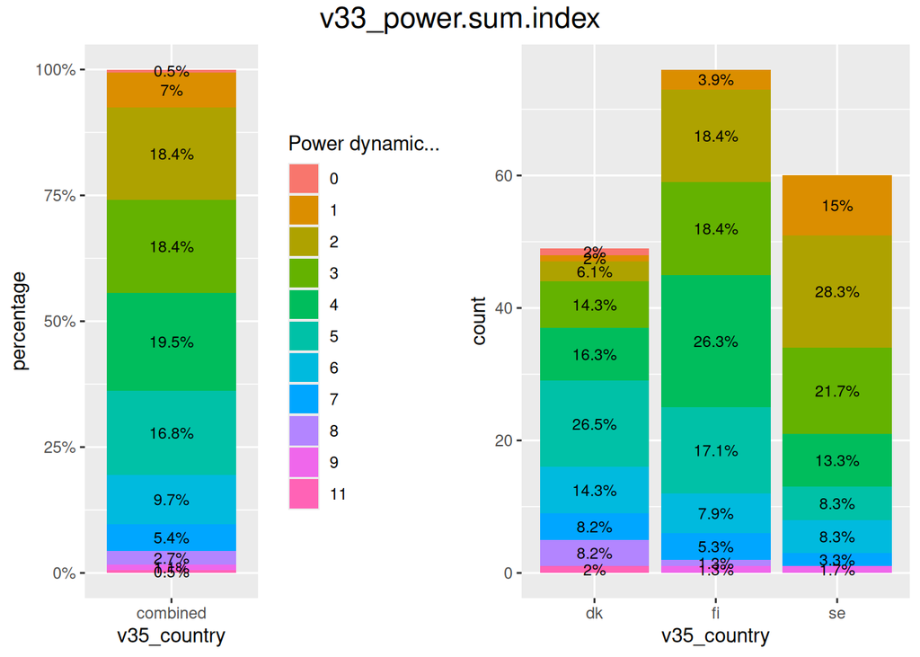

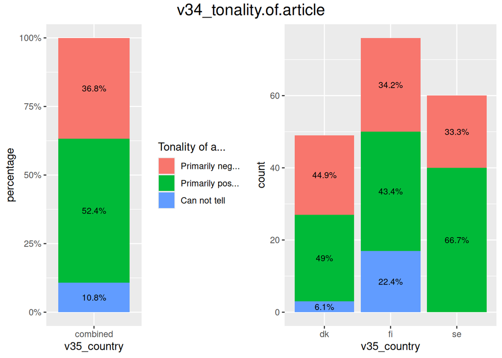

```r
for (i in 33:34) {
pl = desc_get(data, get(paste0("dt",i)), i)
}
```

## 231018: descriptives

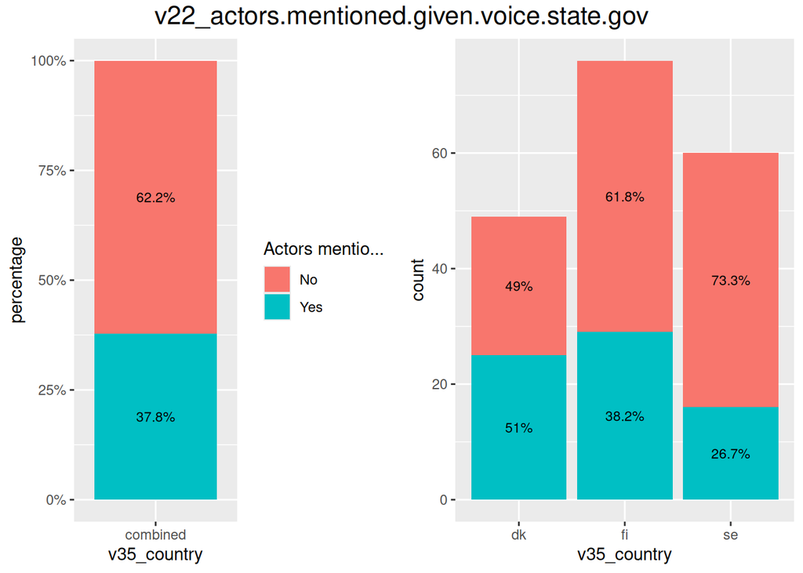

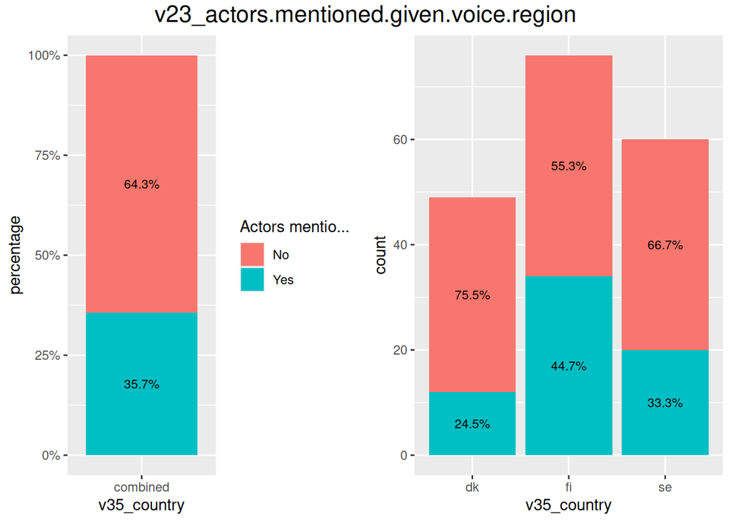

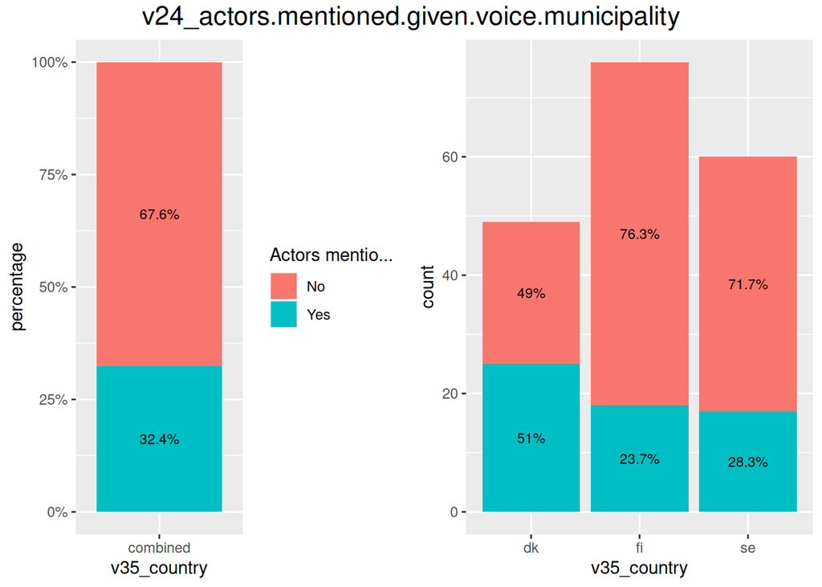

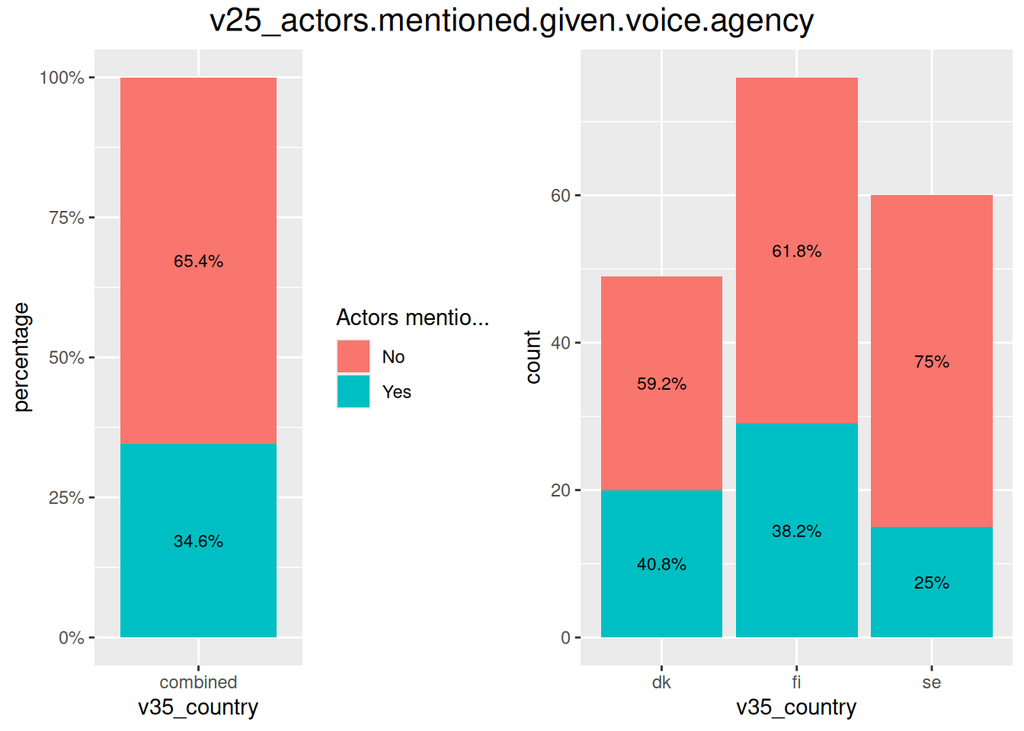

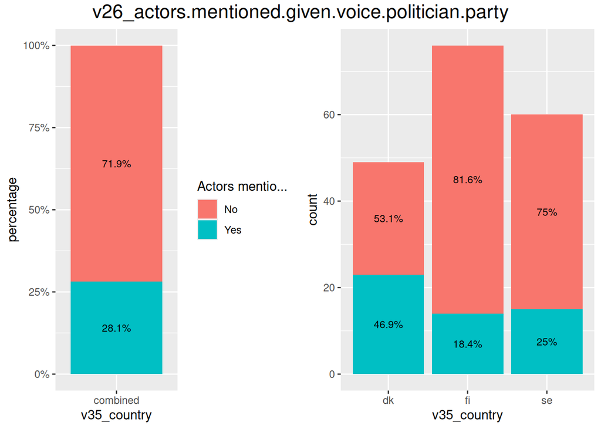

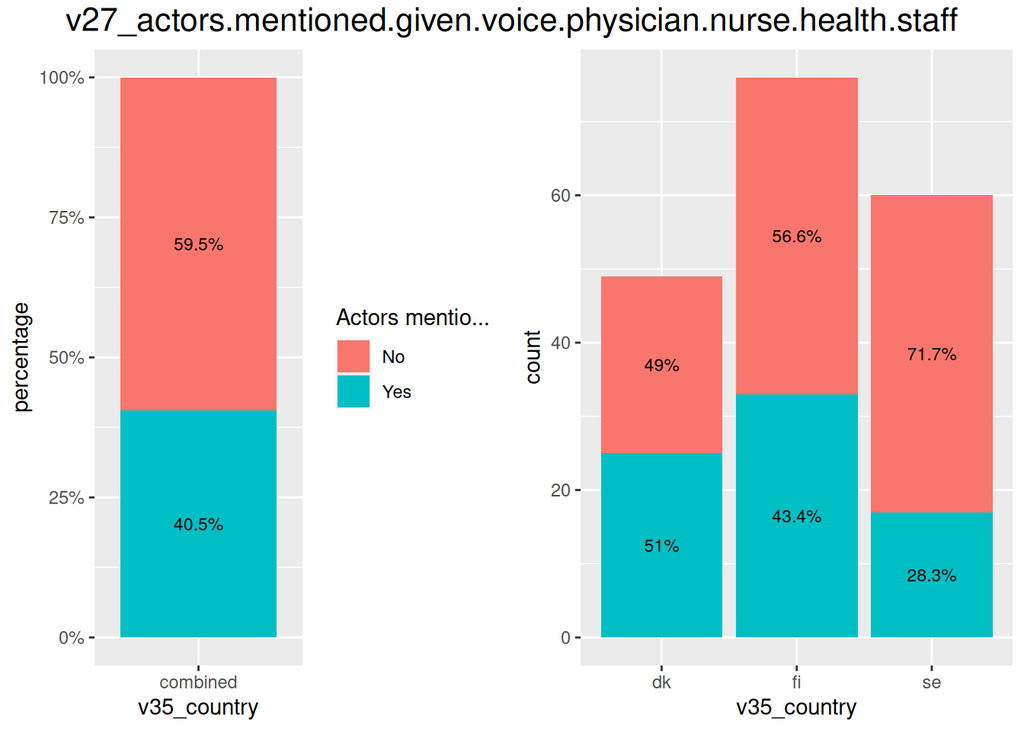

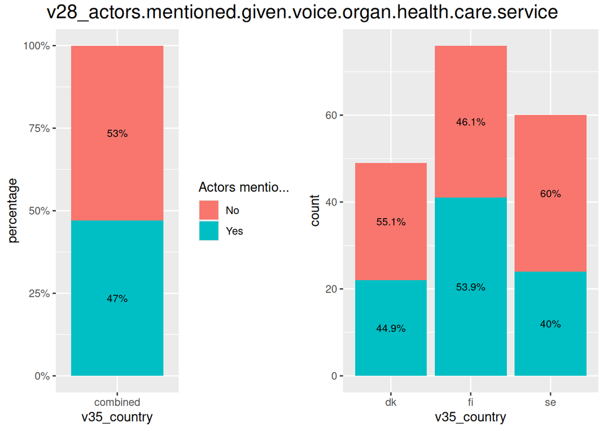

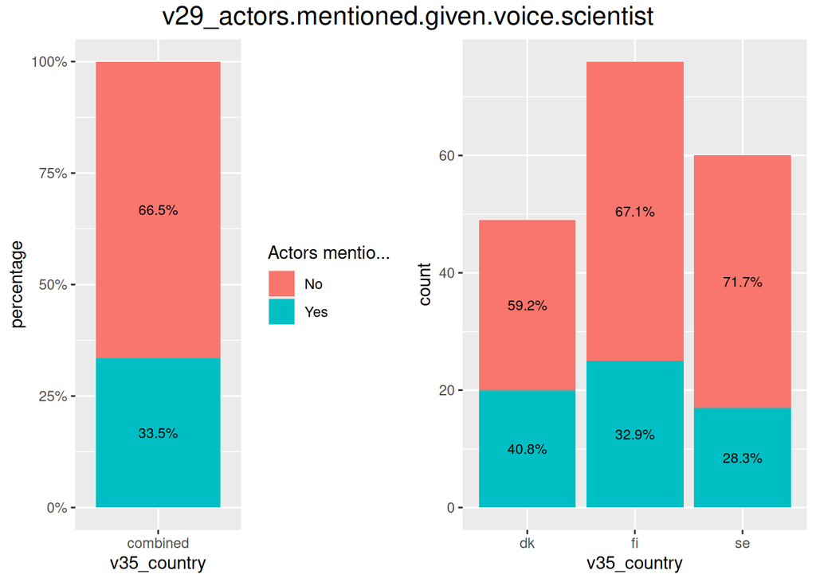

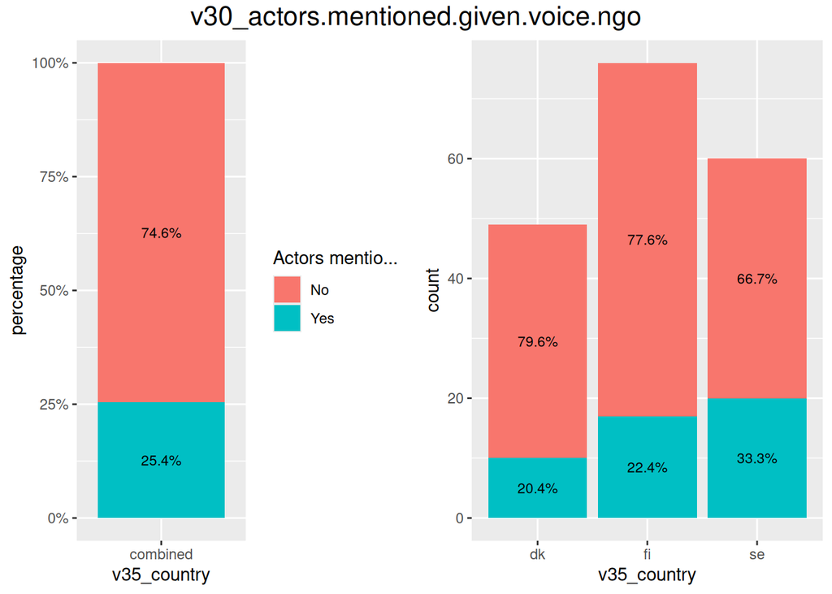

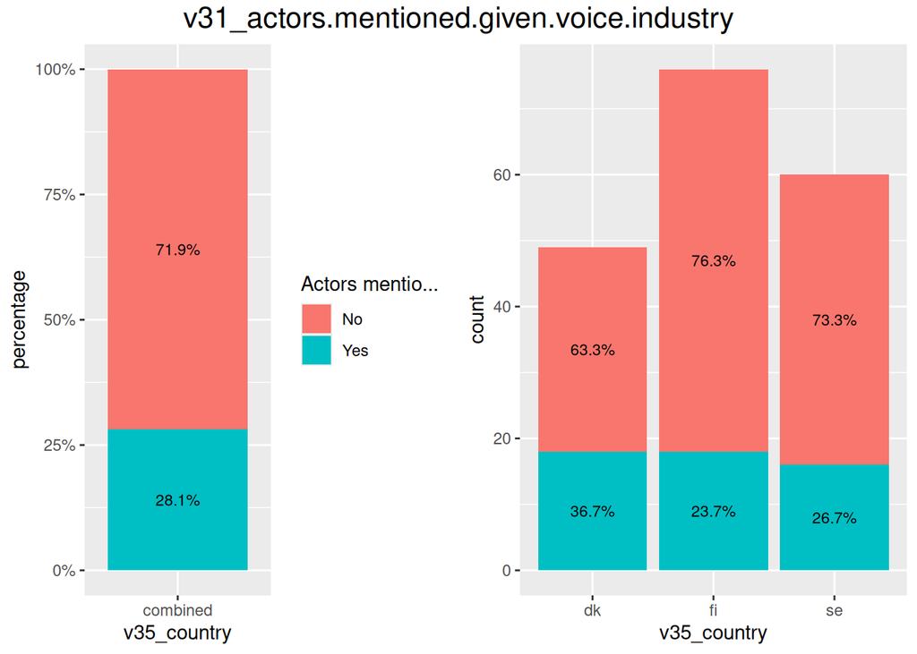

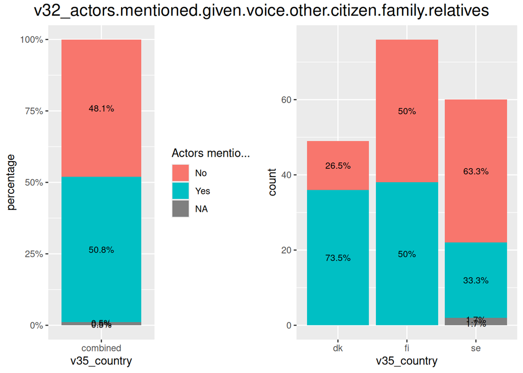

```r
for (i in 22:32) {
pl = desc_get(data, get(paste0("dt",i)), i)
}
```

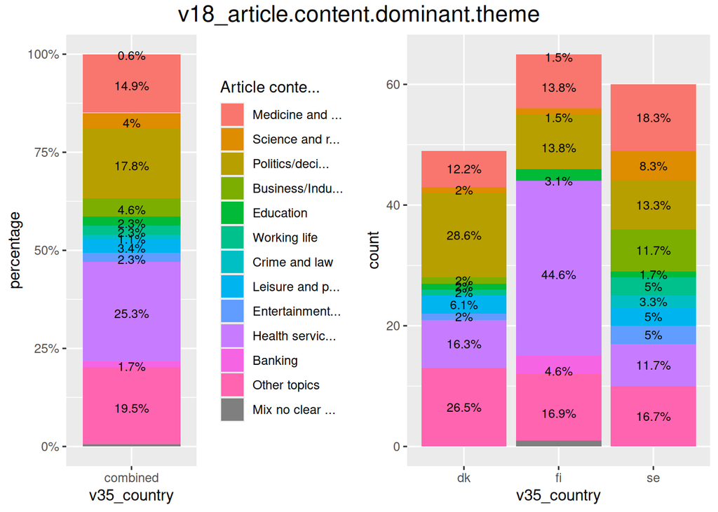

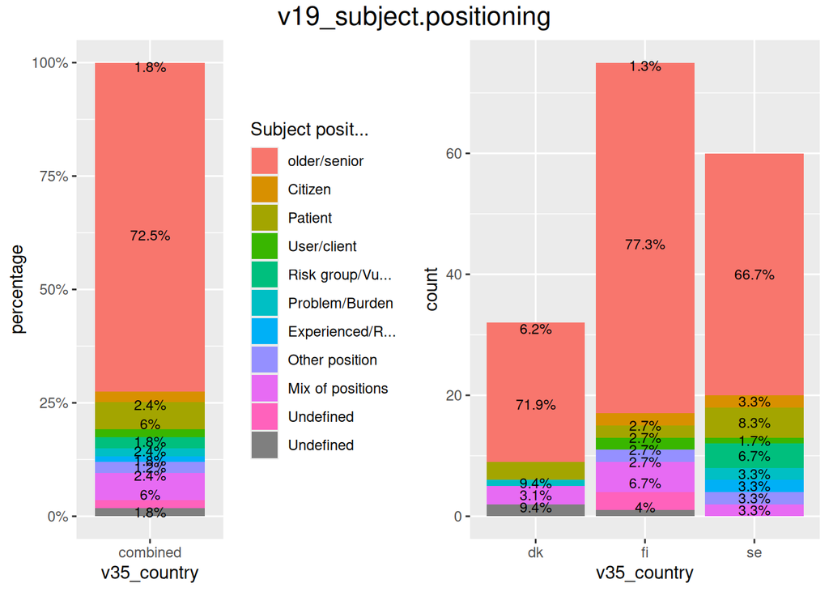

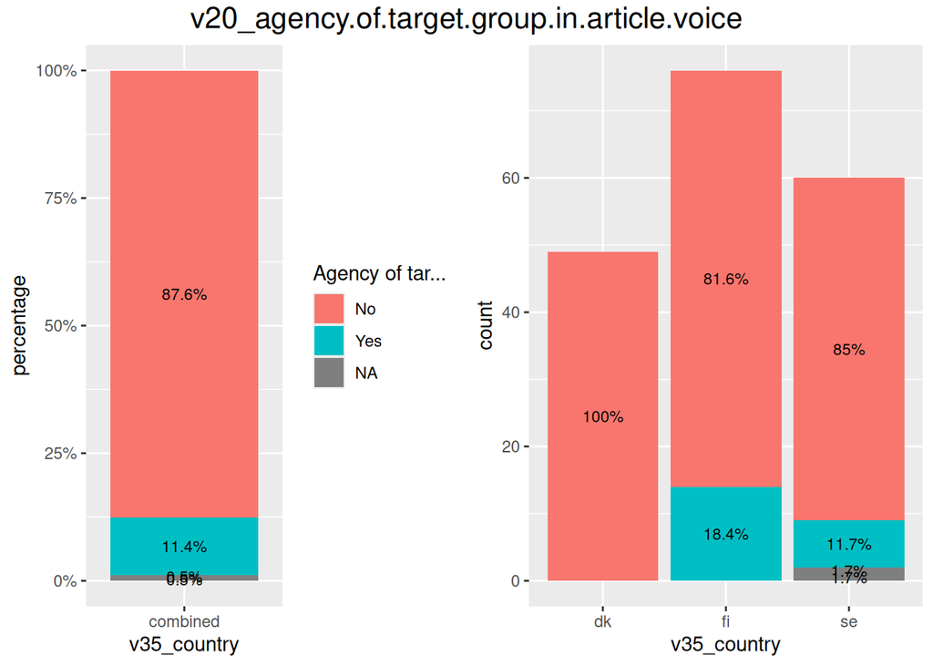

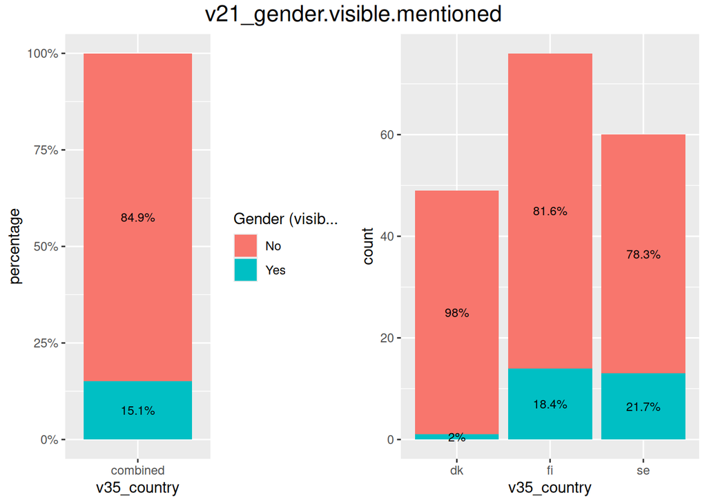

```r
for (i in 18:21) {
pl = desc_get(data, get(paste0("dt",i)), i)
}
```

## 231017: descriptives

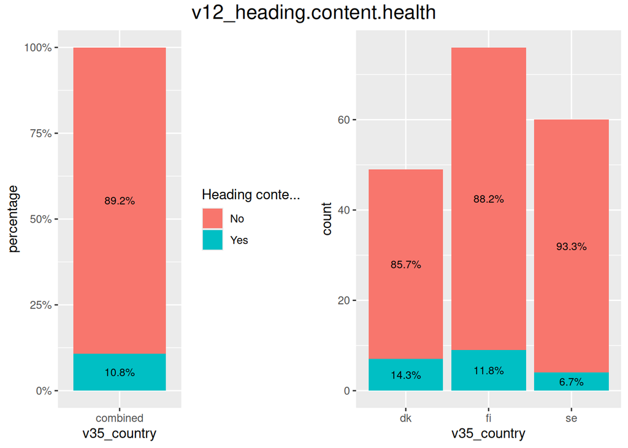

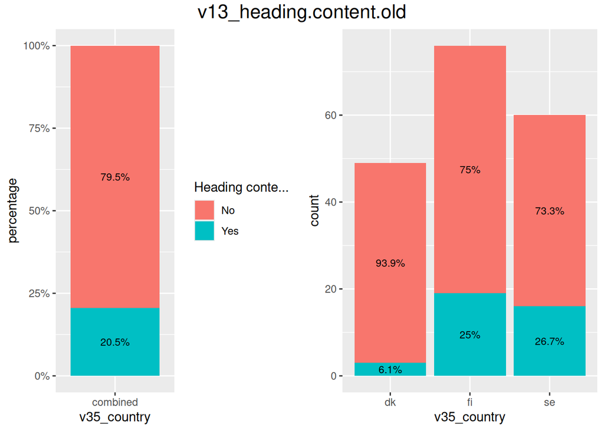

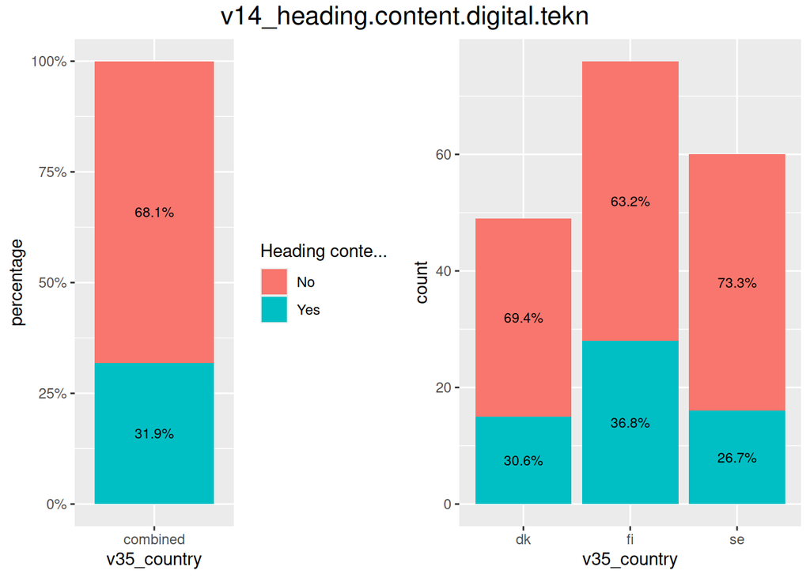

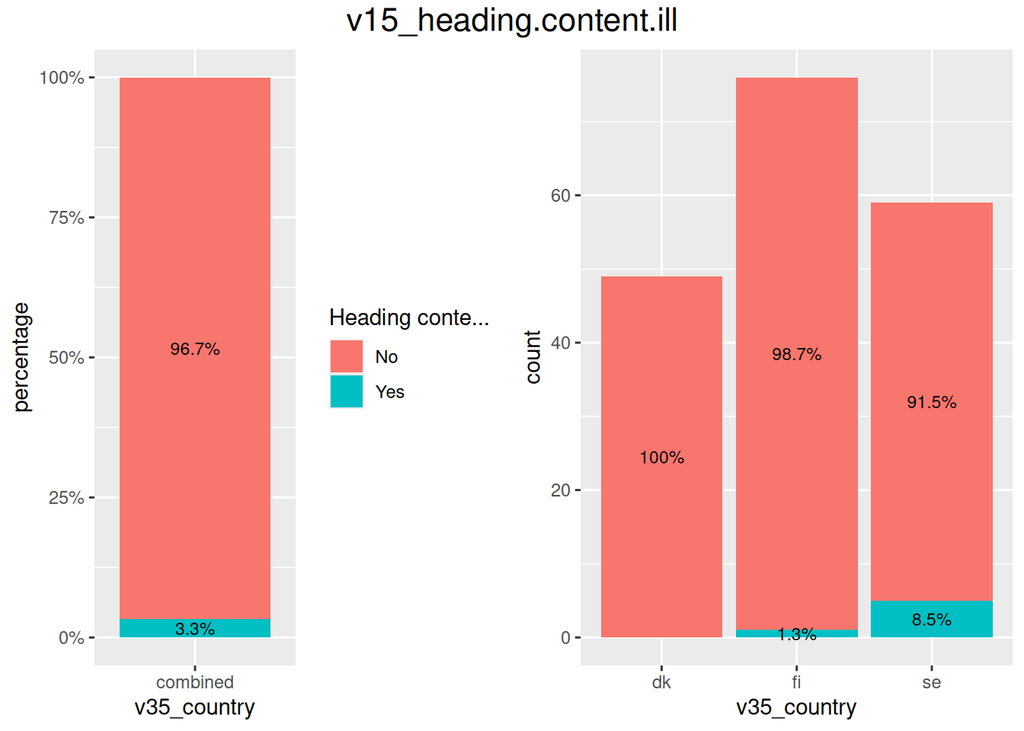

```r
for (i in 12:15) {
pl = desc_get(data, get(paste0("dt",i)), i)
}
```

## 231016: descriptives

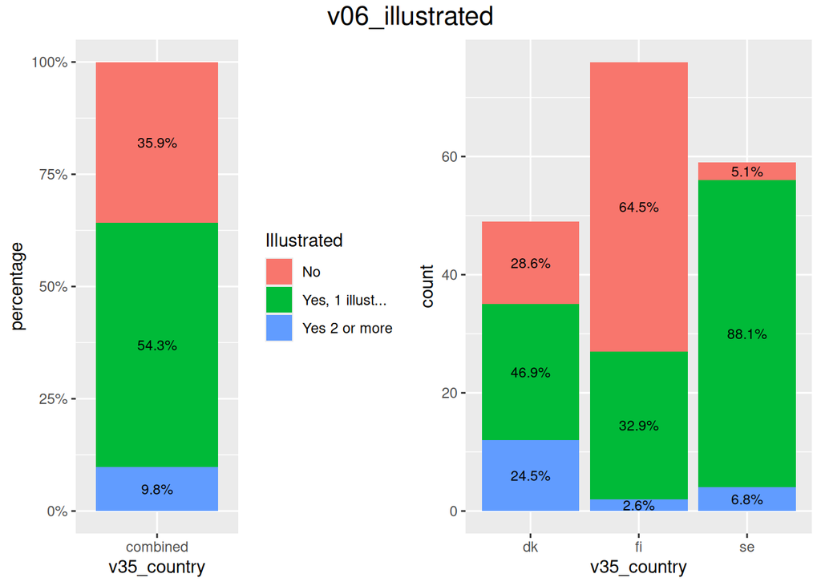

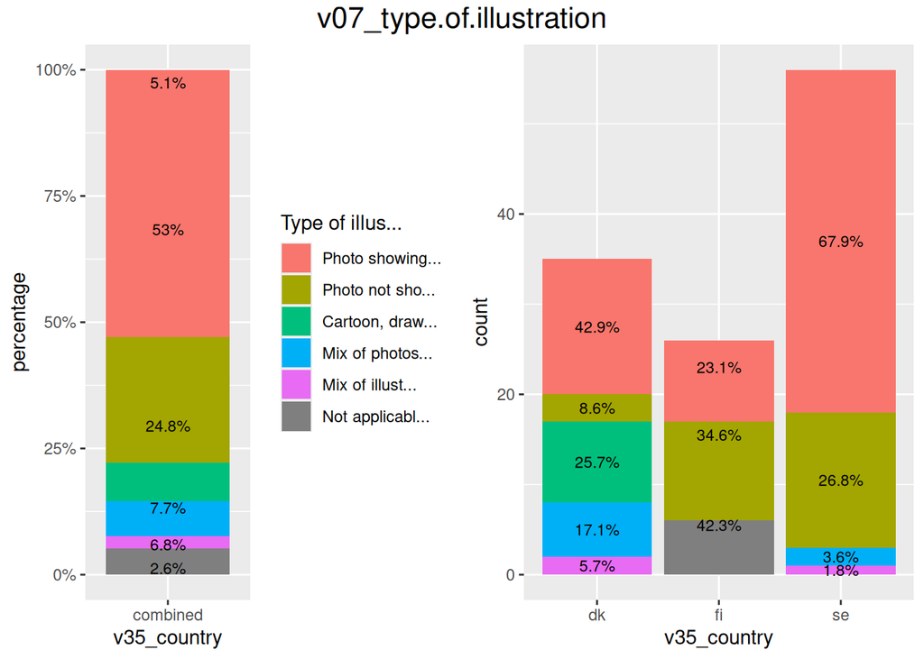

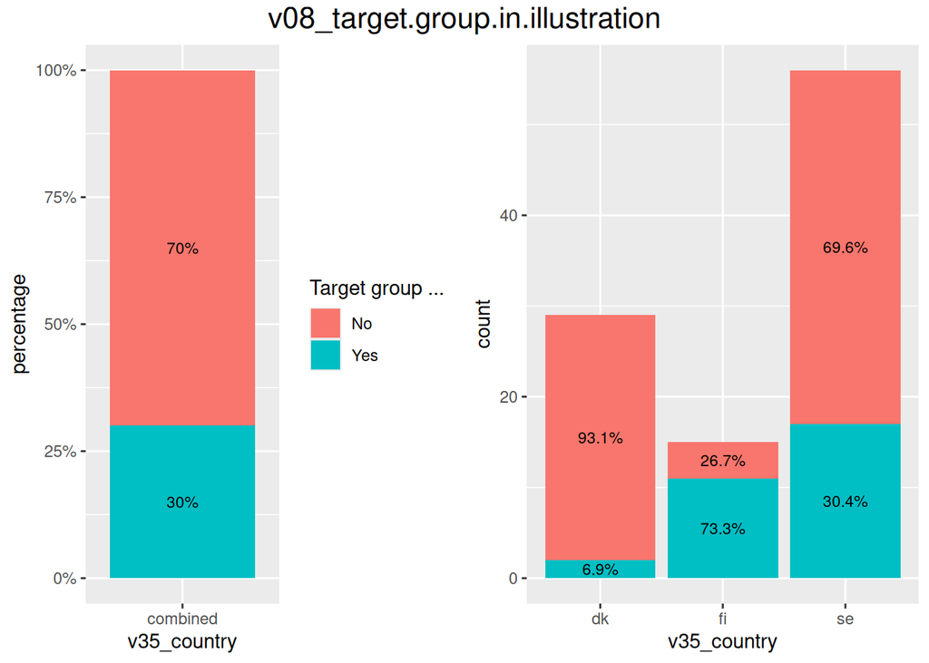

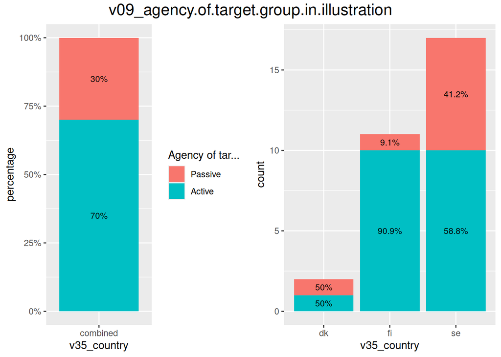

```r
for (i in 6:9) {
pl = desc_get(data, get(paste0("dt0",i)), i)
}
```

- figures [link](https://github.com/nils-holmberg/socs-qmd/tree/main/fig/haidi)

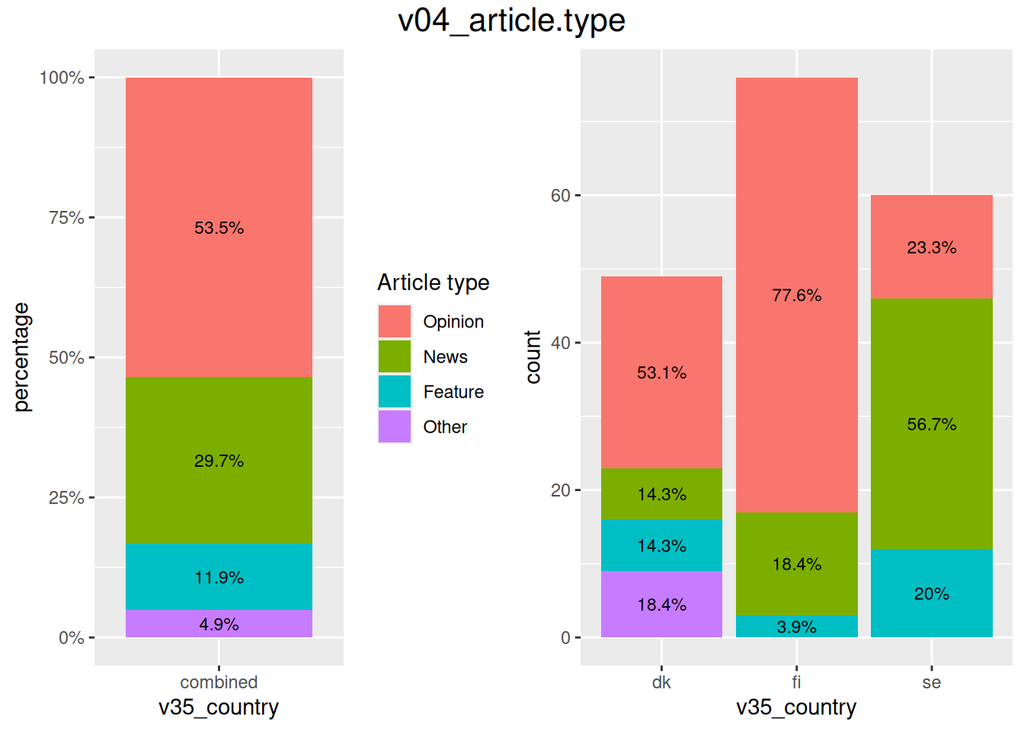

```r
pl = desc_get(data, dt04, 4)
```

```r
#grid.arrange(pl[1], pl[2], ncol=2, widths=c(3, 4))
```

## 231012: descriptives

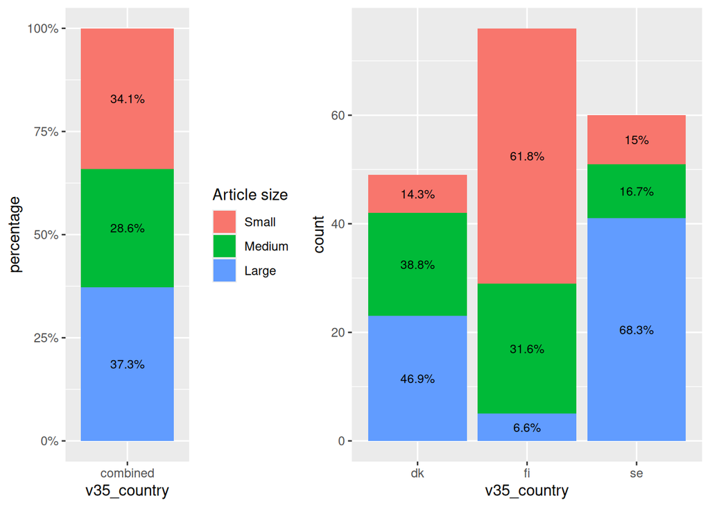

```r
# plot data, grouped
pdg = data |>
group_by(v35_country, v05_article.size) |>
summarize(count=n()) |>
mutate(prop=count/sum(count)) |>
mutate(prop_lab=rev(cumsum(rev(prop)))-prop/2) |>
mutate(count_lab=rev(cumsum(rev(count)))-count/2) |>
left_join(dt05 |> as_tibble() |> arrange(V2), by=join_by(v05_article.size==V2), keep=T)
#
p1 = ggplot(data=pdg, aes(fill=as.factor(V2), y=count, x=v35_country)) +
    geom_bar(position="fill", stat="identity") +
    scale_y_continuous(labels=scales::percent) +
#    geom_text(aes(label=paste0(prop*100,"%")), position=position_stack(vjust=0.5), size=2)
    geom_text(aes(label=paste0(round(100*prop,1),"%"), y=prop_lab), size=3) +
    scale_fill_discrete(name=dt05$V1[1], labels=dt05$V3)

#
p2 = ggplot(data=pdg, aes(fill=as.factor(V2), y=count, x=v35_country)) +
    geom_bar(position="stack", stat="identity") +
    geom_text(aes(label=count, y=count_lab), size=3) +
    scale_fill_discrete(name=dt05$V1[1], labels=dt05$V3)

#
p3 = ggplot(data=pdg, aes(fill=as.factor(V2), y=count, x=v35_country)) +
    geom_bar(position="stack", stat="identity") +
#    geom_text(aes(label=count, y=count_lab), size=3) +
    geom_text(aes(label=paste0(round(100*prop,1),"%"), y=count_lab), size=3) +
#    scale_fill_discrete(name=dt05$V1[1], labels=dt05$V3)
    scale_fill_discrete(guide="none")

# plot data, combined
pdc = data |>
group_by(v05_article.size) |>
summarize(count=n()) |>
mutate(prop=count/sum(count)) |>
mutate(prop_lab=rev(cumsum(rev(prop)))-prop/2) |>
mutate(count_lab=rev(cumsum(rev(count)))-count/2) |>
left_join(dt05 |> as_tibble(), by=join_by(v05_article.size==V2), keep=T)

#
p4 = ggplot(data=pdc, aes(fill=as.factor(V2), y=count, x="combined")) +
    geom_bar(position="fill", stat="identity") +
    scale_y_continuous(labels=scales::percent) +
    geom_text(aes(label=paste0(round(100*prop,1),"%"), y=prop_lab), size=3) +
    scale_fill_discrete(name=dt05$V1[1], labels=dt05$V3) +
    labs(y="percentage", x="v35_country")

#par(mfrow = c(1,2))
#pdf("../fig/foo.pdf")#png()
grid.arrange(p4, p3, ncol=2, widths=c(3, 4))
```

```r
#dev.off()
```

- combined dataset link

## 231009: dk icr re-test

```r
# load dataset
fn = "../csv/haidi-wp1-coding-dk-2.tsv"
#data = read.table(fn, sep='\t', header=F, strip.white=TRUE, stringsAsFactors=FALSE, quote="")
data = read.table(fn, sep='\t', header=F, strip.white=TRUE, stringsAsFactors=FALSE) |> as_tibble()

# select data
data = data |>
na.omit() |>
select(-c(2)) |>
select(last_col(), 1:29) |>
rename(coder_id=V31, content_id=V1)
# content_id for both coders
data$some = data$content_id
# clean data
#data$V3 = data$V3 |> str_extract("\\d+") |> as.numeric()
```

### analyze data

```r
#
write.table(data, "../csv/haidi-dk-2.tsv", sep="\t", quot=T, row.names=F)
# transform data to wide (10 content units * 28 content vars)
data = data |>
pivot_wider(id_cols=coder_id, names_from=some, values_from=c(3:30)) |>
select(-coder_id)
#
data
```

```
# A tibble: 2 × 280
  V3_DK001 V3_DK002 V3_DK003 V3_DK004 V3_DK005 V3_DK006 V3_DK007 V3_DK008
     <int>    <int>    <int>    <int>    <int>    <int>    <int>    <int>
1      208      206      208      206      206      206      206      206
2      208      206      208      206      206      206      206      206
# ℹ 272 more variables: V3_DK009 <int>, V3_DK010 <int>, V4_DK001 <int>,
#   V4_DK002 <int>, V4_DK003 <int>, V4_DK004 <int>, V4_DK005 <int>,
#   V4_DK006 <int>, V4_DK007 <int>, V4_DK008 <int>, V4_DK009 <int>,
#   V4_DK010 <int>, V5_DK001 <int>, V5_DK002 <int>, V5_DK003 <int>,
#   V5_DK004 <int>, V5_DK005 <int>, V5_DK006 <int>, V5_DK007 <int>,
#   V5_DK008 <int>, V5_DK009 <int>, V5_DK010 <int>, V6_DK001 <int>,
#   V6_DK002 <int>, V6_DK003 <int>, V6_DK004 <int>, V6_DK005 <int>, …
```

```r
# inter rater reliability
data = as.matrix(data)
# specify data type: nominal, ordinal, interval, ratio
kripp.alpha(data, method="nominal")
```

```
 Krippendorff's alpha

 Subjects = 280
   Raters = 2
    alpha = 0.704
```

```r
# write data
fn = "../csv/haidi-wp1-coding-dk-2-wide.csv"
write.table(data, fn, sep="\t", quot=T, row.names=F)
```

- dataset wide format link

## 231004: all

```bash
# bash code chunk
head -n1 ../csv/haidi-all.tsv | tr '\t' '\n' | cat -n | head
```

```
     1  "coder_id"
     2  "content_id"
     3  "V3"
     4  "V4"
     5  "V5"
     6  "V6"
     7  "V7"
     8  "V8"
     9  "V9"
    10  "V12"
```

```r
# load datasets
fn = "../csv/haidi-all.tsv"
data = read.table(fn, sep='\t', header=T, strip.white=TRUE, stringsAsFactors=FALSE) |> as_tibble()

data |> group_by(content_id, coder_id) |> summarize(count=n())
```

```
# A tibble: 60 × 3
# Groups:   content_id [40]
   content_id coder_id count
   <chr>      <chr>    <int>
 1 DK001      A            1
 2 DK001      B            1
 3 DK002      A            1
 4 DK002      B            1
 5 DK003      A            1
 6 DK003      B            1
 7 DK004      A            1
 8 DK004      B            1
 9 DK005      A            1
10 DK005      B            1
# ℹ 50 more rows
```

```r
data |> group_by(V4) |> summarize(count=n())
```

```
# A tibble: 4 × 2
     V4 count
  <int> <int>
1     1    44
2     2    10
3     3     3
4     4     3
```

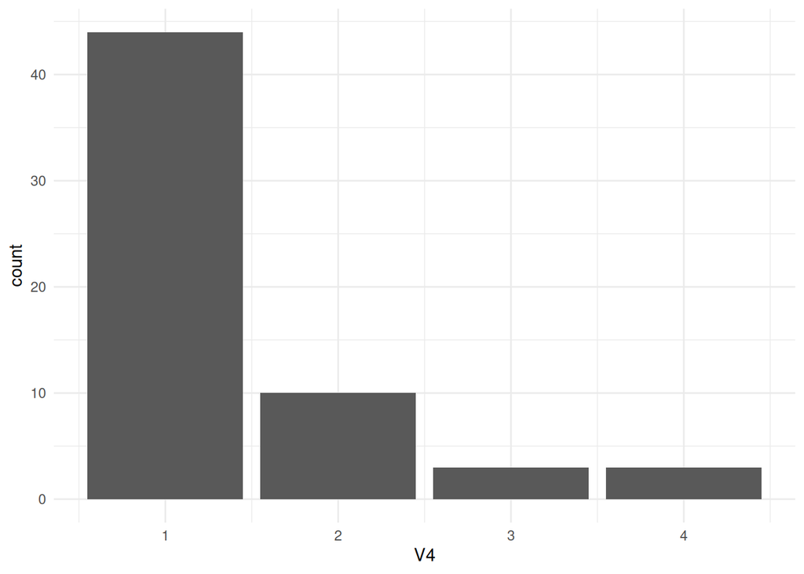

```r
data |> group_by(V4) |> summarize(count=n()) |>
ggplot(aes(x=V4, y=count)) +
#  geom_bar(fill="green", stat="identity") +
  geom_bar(stat="identity") +
  theme_minimal()
```

```r
data |> group_by(V4) |> summarize(count=n()) |> arrange(desc(V4)) |> mutate(prop=round(count*100/sum(count), 1), lab.ypos=cumsum(prop) - 0.5*prop)
```

```
# A tibble: 4 × 4
     V4 count  prop lab.ypos
  <int> <int> <dbl>    <dbl>
1     4     3   5        2.5
2     3     3   5        7.5
3     2    10  16.7     18.4
4     1    44  73.3     63.4
```

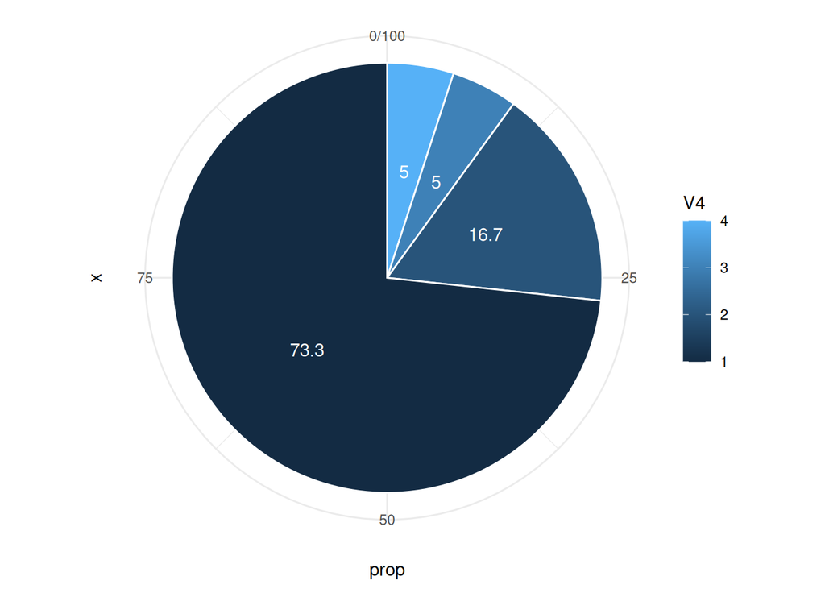

```r
data |> group_by(V4) |> summarize(count=n()) |> arrange(desc(V4)) |> mutate(prop=round(count*100/sum(count), 1), lab.ypos=cumsum(prop) - 0.5*prop) |>
ggplot(aes(x="", y=prop, fill=V4)) +
  geom_bar(width=1, stat="identity", color="white") +
  geom_text(aes(y=lab.ypos, label=prop), color="white") +
  coord_polar("y", start=0) +
  theme_minimal()
```

## 231003: all datasets

```r
# load datasets
fn = "../csv/haidi-dk.tsv"
data_dk = read.table(fn, sep='\t', header=T, strip.white=TRUE, stringsAsFactors=FALSE)
fn = "../csv/haidi-fi.tsv"
data_fi = read.table(fn, sep='\t', header=T, strip.white=TRUE, stringsAsFactors=FALSE)
fn = "../csv/haidi-se.tsv"
data_se = read.table(fn, sep='\t', header=T, strip.white=TRUE, stringsAsFactors=FALSE)

data = rbind(data_dk, data_fi, data_se)
data |> as_tibble()
```

```
# A tibble: 60 × 31
   coder_id content_id    V3    V4    V5    V6    V7    V8    V9   V12   V13
   <chr>    <chr>      <int> <int> <int> <int> <int> <int> <int> <int> <int>
 1 A        DK001        208     4     3     2     1     0    99     0     0
 2 A        DK002        206     4     3     2     4     0    99     0     0
 3 A        DK003        208     1     2     0    99     0    99     0     0
 4 A        DK004        206     1     3     1     3     0    99     0     0
 5 A        DK005        206     1     2     0    99     0    99     0     0
 6 A        DK006        206     1     3     1     3     0    99     0     0
 7 A        DK007        206     1     3     0    99     0    99     0     0
 8 A        DK008        206     1     2     1     3     0    99     0     0
 9 A        DK009        206     1     2     1     3     0    99     1     0
10 A        DK010        206     1     1     0    99    99    99     0     0
# ℹ 50 more rows
# ℹ 20 more variables: V14 <int>, V15 <int>, V18 <int>, V19 <int>, V20 <int>,
#   V21 <int>, V22 <int>, V23 <int>, V24 <int>, V25 <int>, V26 <int>,
#   V27 <int>, V28 <int>, V29 <int>, V30 <int>, V31 <int>, V32 <int>,
#   V33 <int>, V34 <int>, some <chr>
```

```r
#
write.table(data, "../csv/haidi-all.tsv", sep="\t", quot=T, row.names=F)
```

- all datasets link

## 230525: finnish dataset

```r
# load dataset
fn = "../csv/haidi-wp1-coding-fi.tsv"
#data = read.table(fn, sep='\t', header=F, strip.white=TRUE, stringsAsFactors=FALSE)
data = read.table(fn, sep='\t', header=F, quote="", strip.white=TRUE, stringsAsFactors=FALSE)
# select data
data = data |>
as_tibble() |>
na.omit() |>
select(-c(2,10,11,16,17)) |>
select(last_col(), 1:29) |>
rename(coder_id=V35, content_id=V1)
# content_id for both coders
data$some = data$content_id
# clean data
data$V3 = data$V3 |> str_extract("\\d+") |> as.numeric()
```

### analyze data

```r
#
write.table(data, "../csv/haidi-fi.tsv", sep="\t", quot=T, row.names=F)
# transform data to wide (10 content units * 28 content vars)
data = data |>
pivot_wider(id_cols=coder_id, names_from=some, values_from=c(3:30)) |>
select(-coder_id)
#
data
```

```
# A tibble: 2 × 280
  V3_FI001 V3_FI002 V3_FI003 V3_FI004 V3_FI005 V3_FI006 V3_FI007 V3_FI008
     <dbl>    <dbl>    <dbl>    <dbl>    <dbl>    <dbl>    <dbl>    <dbl>
1      315      311      311      313      314      315      315      314
2      315      311      311      313      314      315      315      314
# ℹ 272 more variables: V3_FI009 <dbl>, V3_FI010 <dbl>, V4_FI001 <int>,
#   V4_FI002 <int>, V4_FI003 <int>, V4_FI004 <int>, V4_FI005 <int>,
#   V4_FI006 <int>, V4_FI007 <int>, V4_FI008 <int>, V4_FI009 <int>,
#   V4_FI010 <int>, V5_FI001 <int>, V5_FI002 <int>, V5_FI003 <int>,
#   V5_FI004 <int>, V5_FI005 <int>, V5_FI006 <int>, V5_FI007 <int>,
#   V5_FI008 <int>, V5_FI009 <int>, V5_FI010 <int>, V6_FI001 <int>,
#   V6_FI002 <int>, V6_FI003 <int>, V6_FI004 <int>, V6_FI005 <int>, …
```

```r
# inter rater reliability
data = as.matrix(data)
# specify data type: nominal, ordinal, interval, ratio
kripp.alpha(data, method="nominal")
```

```
 Krippendorff's alpha

 Subjects = 280
   Raters = 2
    alpha = 0.72
```

```r
# write data
fn = "../csv/haidi-wp1-coding-fi-wide.csv"
write.table(data, fn, sep="\t", quot=T, row.names=F)
```

- dataset wide format link

## 230523: danish dataset

```r
# load dataset
fn = "../csv/haidi-wp1-coding-dk.tsv"
data = read.table(fn, sep='\t', header=F, strip.white=TRUE, stringsAsFactors=FALSE)
data = read.table(fn, sep='\t', header=F, quote="", strip.white=TRUE, stringsAsFactors=FALSE)
# select data
data = data |>
as_tibble() |>
na.omit() |>
select(-c(2,10,11,16,17)) |>
select(last_col(), 1:29) |>
rename(coder_id=V35, content_id=V1)
# content_id for both coders
data$some = data$content_id
# clean data
data$V18 = data$V18 |> str_extract("^\\d+") |> as.numeric()
```

### analyze data

```r
#
write.table(data, "../csv/haidi-dk.tsv", sep="\t", quot=T, row.names=F)
# transform data to wide (10 content units * 28 content vars)
data = data |>
pivot_wider(id_cols=coder_id, names_from=some, values_from=c(3:30)) |>
select(-coder_id)
#
data
```

```
# A tibble: 2 × 280
  V3_DK001 V3_DK002 V3_DK003 V3_DK004 V3_DK005 V3_DK006 V3_DK007 V3_DK008
     <int>    <int>    <int>    <int>    <int>    <int>    <int>    <int>
1      208      206      208      206      206      206      206      206
2      208      206      208      206      206      206      206      206
# ℹ 272 more variables: V3_DK009 <int>, V3_DK010 <int>, V4_DK001 <int>,
#   V4_DK002 <int>, V4_DK003 <int>, V4_DK004 <int>, V4_DK005 <int>,
#   V4_DK006 <int>, V4_DK007 <int>, V4_DK008 <int>, V4_DK009 <int>,
#   V4_DK010 <int>, V5_DK001 <int>, V5_DK002 <int>, V5_DK003 <int>,
#   V5_DK004 <int>, V5_DK005 <int>, V5_DK006 <int>, V5_DK007 <int>,
#   V5_DK008 <int>, V5_DK009 <int>, V5_DK010 <int>, V6_DK001 <int>,
#   V6_DK002 <int>, V6_DK003 <int>, V6_DK004 <int>, V6_DK005 <int>, …
```

```r
# inter rater reliability
data = as.matrix(data)
# specify data type: nominal, ordinal, interval, ratio
kripp.alpha(data, method="nominal")
```

```
 Krippendorff's alpha

 Subjects = 280
   Raters = 2
    alpha = 0.639
```

```r
# write data
fn = "../csv/haidi-wp1-coding-dk-wide.csv"
write.table(data, fn, sep="\t", quot=T, row.names=F)
```

- dataset wide format link

## 230515: swedish dataset

```r
# load dataset
fn = "../csv/some.tsv"
data = read.table(fn, sep='\t', header=F, strip.white=TRUE, stringsAsFactors=FALSE)
data = read.table(fn, sep='\t', header=F, quote="", strip.white=TRUE, stringsAsFactors=FALSE)
# select data
data = data |> as_tibble() |> select(-c(2,10,11,16,17)) |> select(last_col(), 1:29) |> rename(coder_id=V35, content_id=V1)
# duplicate content_id for both coders
data$some = rep(data$content_id[data$coder_id=="A"], 2)
```

## 230516: analyze data

```r
#
write.table(data, "../csv/haidi-se.tsv", sep="\t", quot=T, row.names=F)
# transform data to wide (10 content units * 28 content vars)
data = data |>
pivot_wider(id_cols=coder_id, names_from=some, values_from=c(3:30)) |>
select(-coder_id)
#
data
```

```
# A tibble: 2 × 280
  V3_S001 V3_S002 V3_S003 V3_S004 V3_S005 V3_S006 V3_S007 V3_S008 V3_S009
    <int>   <int>   <int>   <int>   <int>   <int>   <int>   <int>   <int>
1     102     103     102     101     104     102     103     101     101
2     102     103     102     101     104     102     103     101     101
# ℹ 271 more variables: V3_S010 <int>, V4_S001 <int>, V4_S002 <int>,
#   V4_S003 <int>, V4_S004 <int>, V4_S005 <int>, V4_S006 <int>, V4_S007 <int>,
#   V4_S008 <int>, V4_S009 <int>, V4_S010 <int>, V5_S001 <int>, V5_S002 <int>,
#   V5_S003 <int>, V5_S004 <int>, V5_S005 <int>, V5_S006 <int>, V5_S007 <int>,
#   V5_S008 <int>, V5_S009 <int>, V5_S010 <int>, V6_S001 <int>, V6_S002 <int>,
#   V6_S003 <int>, V6_S004 <int>, V6_S005 <int>, V6_S006 <int>, V6_S007 <int>,
#   V6_S008 <int>, V6_S009 <int>, V6_S010 <int>, V7_S001 <int>, …
```

```r
# inter rater reliability
data = as.matrix(data)
# specify data type: nominal, ordinal, interval, ratio
kripp.alpha(data, method="nominal")
```

```
 Krippendorff's alpha

 Subjects = 280
   Raters = 2
    alpha = 0.784
```

```r
# write data
fn = "../csv/test.csv"
write.table(data, fn, sep="\t", quot=T, row.names=F)
```

- dataset wide format link

## 230426: sample dataset

```r
# load dataset
data = readxl::read_excel('../csv/some.xlsx', sheet="Blad1", col_names=paste0("x", seq(34)))
# select data
data = data |>
mutate(coder_id=c(rep("a",5), rep("b",5)), content_id=rep(seq(5), 2)) |>
select("coder_id","content_id",1,3,9,10) |> print(n=100)
```

```
# A tibble: 10 × 6
   coder_id content_id x1       x3    x9 x10
   <chr>         <int> <chr> <dbl> <dbl> <chr>
 1 a                 1 S001    102    99 Dolda larmsiffrorna: Så dåligt mår 85-…
 2 a                 2 S002    103    99 Satsningar som räddar liv
 3 a                 3 S003    102    99 Detta måste ni rätta till i vården, po…
 4 a                 4 S004    101    99 Sju utmaningar - därför är det kris i …
 5 a                 5 S005    104    99 De kommande årens satsningar sker i pr…
 6 b                 1 S006    102     0 De har full koll på senioren
 7 b                 2 S007    103    99 Mossig kritik mot vårdappar
 8 b                 3 S008    101    99 Folksjukdomar som kan förvärras i spår…
 9 b                 4 S009    101    99 Så vill regeringen möta utmaningarna i…
10 b                 5 S010    105    99 Tekniken ska avlasta personalen
```

```r
# transform data
data = data |>
pivot_wider(id_cols=coder_id, names_from=content_id, values_from=x3) |>
select(-coder_id)
# https://rpubs.com/jacoblong/content-analysis-krippendorff-alpha-R
data
```

```
# A tibble: 2 × 5
    `1`   `2`   `3`   `4`   `5`
  <dbl> <dbl> <dbl> <dbl> <dbl>
1   102   103   102   101   104
2   102   103   101   101   105
```

## 230427: analyze data

```r
# inter rater reliability
data = as.matrix(data)
# specify data type: nominal, ordinal, interval, ratio
kripp.alpha(data, method="nominal")
```

```
 Krippendorff's alpha

 Subjects = 5
   Raters = 2
    alpha = 0.526
```

- Krippendorff’s Alpha values range from -1 to 1, with 1 representing unanimous agreement between the raters, 0 indicating they’re guessing randomly, and negative values suggesting the raters are systematically disagreeing. As suggested by Krippendorff, alphas above 0.8 are considered very good agreement, and tentative conclusions can be made with data where α≥0.667

## sample data

```r
# get some data
data <-
  tribble(
    ~content_id, ~coder_id, ~var1, ~var2,   ~var3,
    1,           "A",       1,     "Red",   FALSE,
    2,           "A",       3,     "Blue",  TRUE,
    3,           "A",       5,     "Blue",  TRUE,
    4,           "A",       7,     "Green", TRUE,
    5,           "A",       1,     "Red",   FALSE,
    1,           "B",       1,     "Red",   FALSE,
    2,           "B",       3,     "Blue",  FALSE,
    3,           "B",       3,     "Green", FALSE,
    4,           "B",       7,     "Green", TRUE,
    5,           "B",       3,     "Red",   FALSE,
  )

data |> print(n=100)
```

```
# A tibble: 10 × 5
   content_id coder_id  var1 var2  var3
        <dbl> <chr>    <dbl> <chr> <lgl>
 1          1 A            1 Red   FALSE
 2          2 A            3 Blue  TRUE
 3          3 A            5 Blue  TRUE
 4          4 A            7 Green TRUE
 5          5 A            1 Red   FALSE
 6          1 B            1 Red   FALSE
 7          2 B            3 Blue  FALSE
 8          3 B            3 Green FALSE
 9          4 B            7 Green TRUE
10          5 B            3 Red   FALSE
```

## exclude

```r
if (T) {
knitr::knit_exit()
}
```